# Calculating climate velocities

Nikki Moore

When faced with changing climate conditions, an organism is expected to track it’s climatic niche through space. Climate velocities are useful metrics that provide ecologists with a way to know how climatic conditions are shifting across a landscape. In this tutorial, we will learn how to calculate different climate velocity metrics using the `VoCC` package.

### Types of climate velocity metrics

There are two types of climate velocities, each having slightly different meanings. Gradient-based velocities are calculated based on local climatic temporal and spatial gradients, while distance-based velocities are calculated based on distance to the nearest analogue (similar) climate.

Below we will discuss each in detail, calculating them as we go and discussing their ecological meanings and exploring their limitations.

#### 1. Gradient-based climate velocities

Gradient-based climate velocities (gVoCC) are a way to describe the propensity of a species to move in response to climate change. They reprenst the ratio between the long-term temporal trend in climate conditions by the spatial gradient in climate conditions:

**gVoCC = long-term trend / spatial gradient**

Let’s try calculating the gVoCC of temperature since 1880. We will use a raster stack of annual average air temperatures from Berkeley Earth:

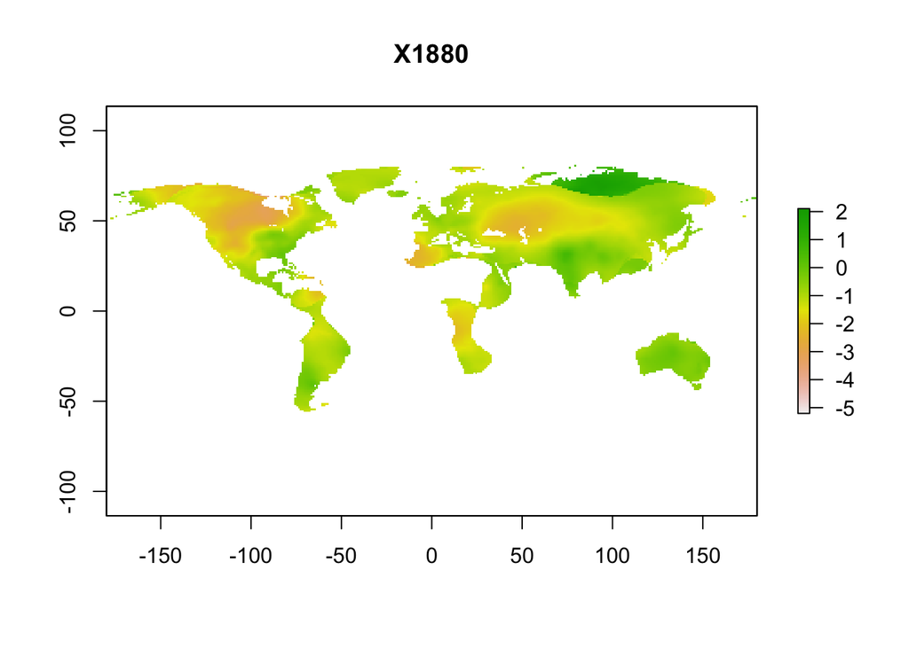

```r
## read in the raster stack:
temps = readRDS(paste(path, "/BerkEarth_rstack_mean.rds", sep = ""))

## plot the first layer (average air temperatures in 1880):
plot(temps[[1]], main = names(temps)[1])
```

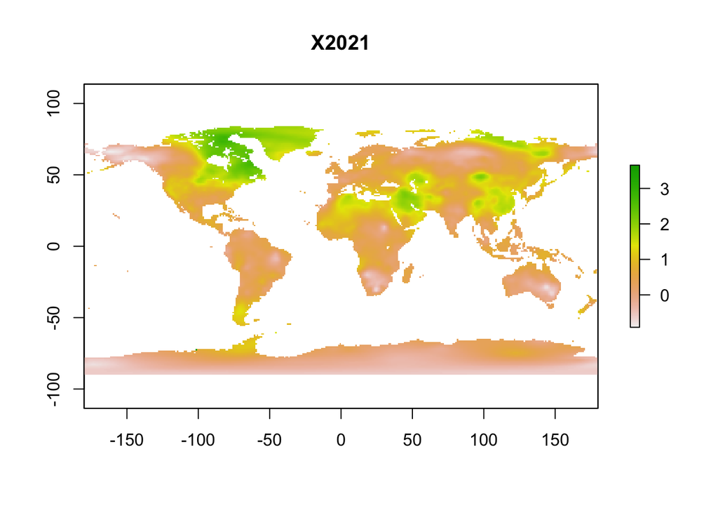

```r
## plot the last layer (average air temperatures in 2021):
plot(temps[[nlayers(temps)]], main = last(names(temps)))
```

First, we need to calculate the temporal trend in temperature across the period 1880-2021 for each raster cell. This is done by fitting a linear regression to the temperature time series from each grid cell. The function `tempTrend` allows us to do this easily:

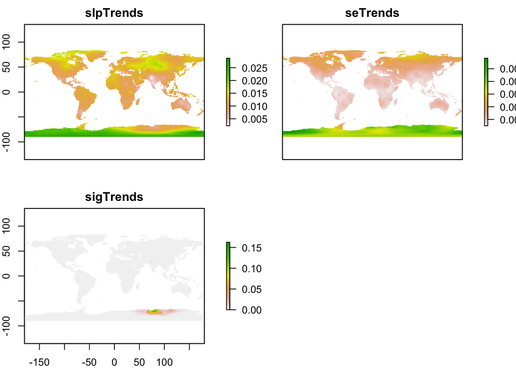

```r
## use function to calculate temporal trend in annual air temperature for each location:
## th = minimum number of observations in the series needed to calculate the trend at each cell
ttrend = tempTrend(r = temps,
                   th = 0.25*nlayers(temps) ## set minimum # obs. to 1/4 time series length
                   )

## plot it:
plot(ttrend)
```

You can see here that the temporal trends (slope of the regressions, slpTrends) show that the climate has warmed faster towards the poles.

Next, we need to calculate the spatial temperature gradient. This is done using the `spatialGrad` function. To use this function, we need to collapse our raster stack into a stack of annual temperature values for each year. I did this for you because it takes a while, so all we have to do is read in the raster:

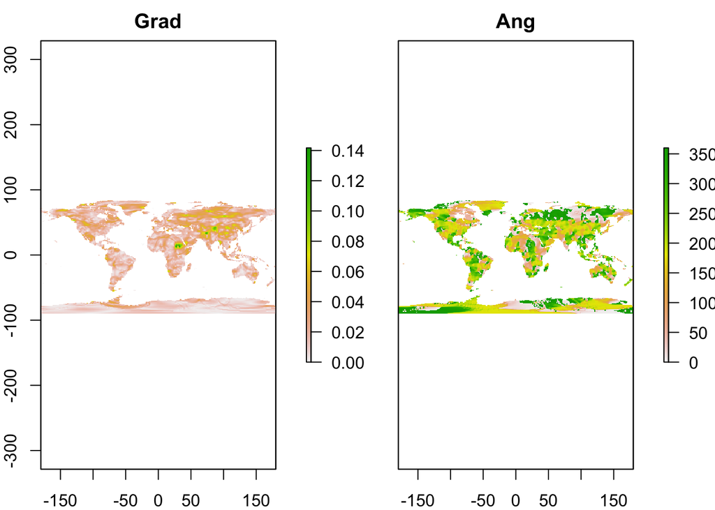

```r
## read in raster of mean annual temperatures:
mean_temps = readRDS(paste(path, "/BerkEarth_rstack_mean.rds", sep = ""))

## use function to calculate spatial gradient in mean daily air temperature for each location:
spgrad = spatGrad(r = mean_temps,
                  projected = TRUE) ## our raster is projected to a coordinate system

## plot it:
plot(spgrad)
```

Spatial resolution really matters for this step. Let’s see what happens when we resample our raster to a coarser resolution before calculating the spatial gradient:

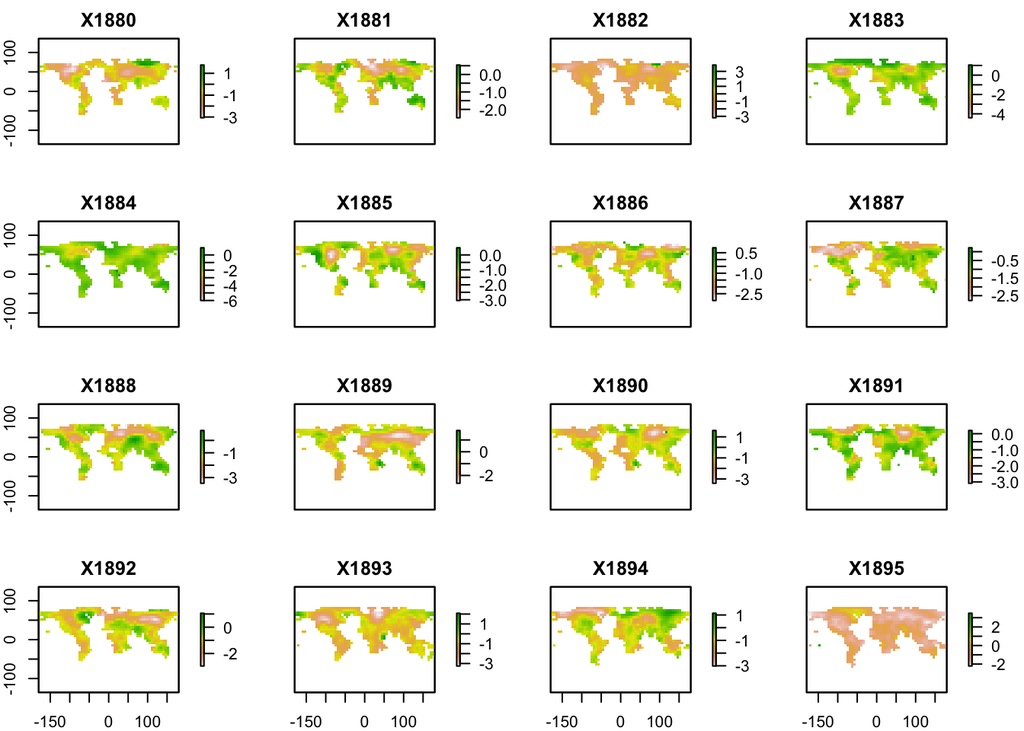

```r
## resample the raster stack to a coarser grain size:
rsamp_temps = aggregate(mean_temps, fact = 6, fun = mean)
plot(rsamp_temps)
```

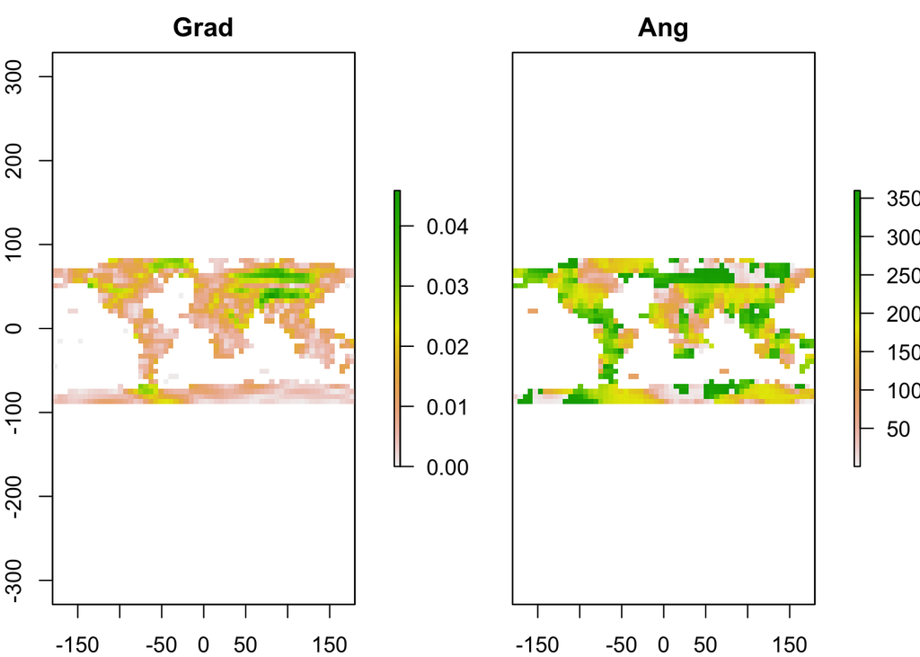

```r
## recalculate the spatial gradient
spgrad_coarse = spatGrad(r = rsamp_temps,
                   projected = TRUE) ## our raster is projected to a coordinate system


## plot it:
plot(spgrad_coarse)
```

```r
max(spgrad$Grad)
```

```
## class      : RasterLayer
## dimensions : 180, 360, 64800  (nrow, ncol, ncell)
## resolution : 1, 1  (x, y)
## extent     : -180, 180, -90, 90  (xmin, xmax, ymin, ymax)
## crs        : +proj=longlat +datum=WGS84 +no_defs
## source     : memory
## names      : Grad
## values     : 0, 0.1417279  (min, max)
```

```r
max(spgrad_coarse$Grad)
```

```
## class      : RasterLayer
## dimensions : 30, 60, 1800  (nrow, ncol, ncell)
## resolution : 6, 6  (x, y)
## extent     : -180, 180, -90, 90  (xmin, xmax, ymin, ymax)
## crs        : +proj=longlat +datum=WGS84 +no_defs
## source     : memory
## names      : Grad
## values     : 0, 0.04589104  (min, max)
```

```r
## spatial averaging makes gradients far less step
```

Now that we have both the temporal trends and spatial gradients, we can compute their ratio to find the gradient-based climate velocity. The function `gVoCC` does this for us:

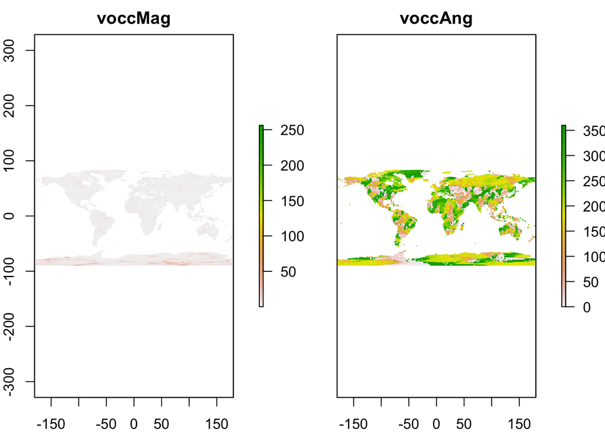

```r
## calculate gradient based climate velocity:
gvocc = gVoCC(tempTrend = ttrend, spatGrad = spgrad)

## plot it:
plot(gvocc)
```

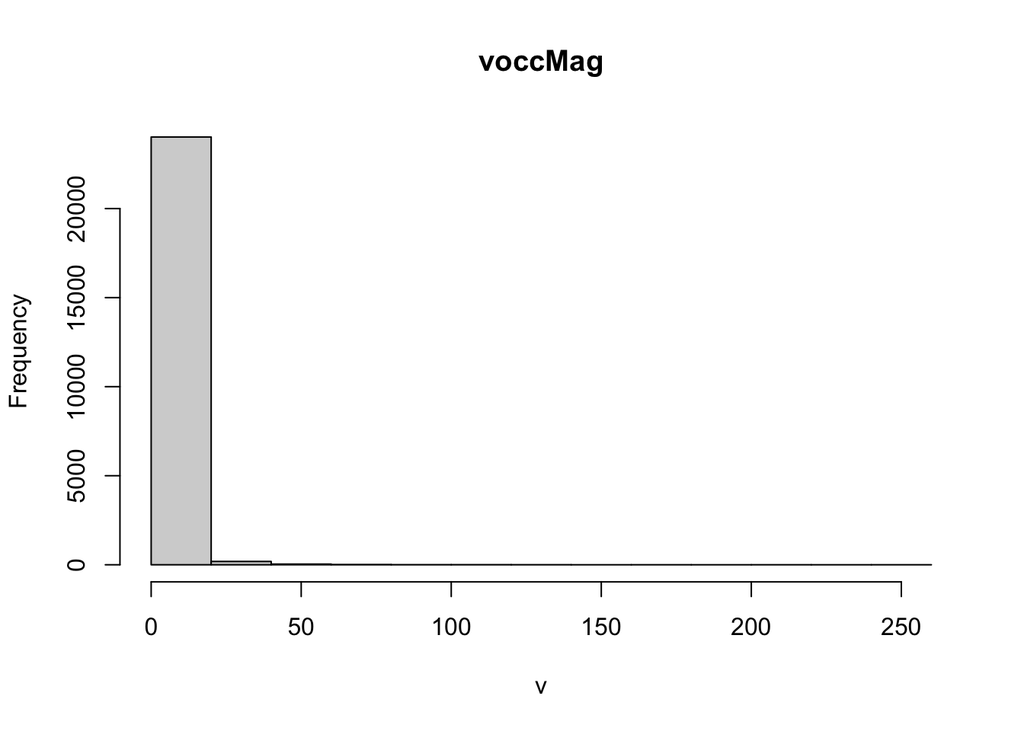

```r
hist(gvocc$voccMag)
```

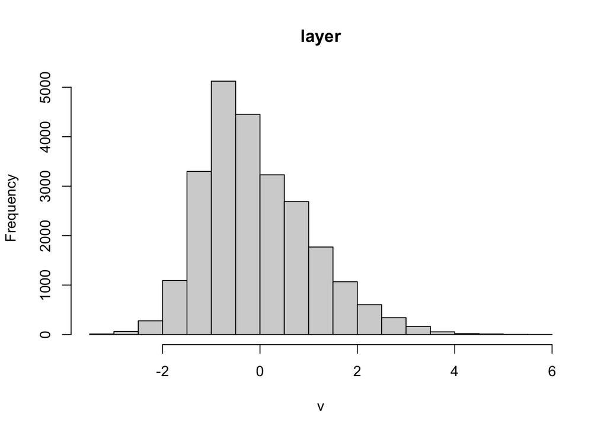

```r
hist(log(gvocc$voccMag))
```